# SNA Reciprocity (Triads and Diads) and Transitivity 33_TOTAL

Leonardo Martins

17 de julho de 2016

SNA Descritive Analysis from “Projeto Redes de Atenção às pessoas que consomem álcool e outras Drogas em Juiz de Fora-MG Brazil” - SNArRDJF

# 1 33_TOTAL

# 2 Loading objects generated with previous script

```r
rm(list = ls()) # removing previous objects to be sure that we don't have objects conflicts name
load("~/SNArRDJF/Robject/8_spanning_tree_total.RData")
```

## 2.1 Reload packages

```r
suppressMessages(library(RColorBrewer))
suppressMessages(library(car))
suppressMessages(library(xtable))
suppressMessages(library(igraph))
suppressMessages(library(miniCRAN))
suppressMessages(library(magrittr))
suppressMessages(library(keyplayer))
suppressMessages(library(dplyr))
suppressMessages(library(feather))
suppressMessages(library(visNetwork))
suppressMessages(library(knitr))
suppressMessages(library(DT))
```

## 2.2 Adding phantom tools

```r
#In order to get dinamic javascript object install those ones. If you get problems installing go to Stackoverflow.com and type your error to discover what to do. In some cases the libraries need to be intalled in outside R libs.
#devtools::install_github("wch/webshot")
#webshot::install_phantomjs()
```

## 2.3 Setting a random seed - this is a good strategy to keep the same graph pattern layout in a new report generation

```r
set.seed(123)
```

## 2.4 Simplify Graph - removing loops and duble edges

```r
#total<-simplify(total) #Simplify
```

# 3 Reciprocity Default

Reciprocity Default - Proportion of mutual connections - probability that hte opposite counterpart of a directed graph is also included

```r
reciprocity(total, mode="default")
```

```
## [1] 0.4124365
```

# 4 Reciprocity Ratio

```r
reciprocity(total, mode="ratio")
```

```
## [1] 0.2597922
```

# 5 Dyad Census

A dyad consists of an unordered pair of actors and links that exist between two actors of the pair classified by mutal non-mutual and no connection in a directed graphs

Dyads are 2-subgraphs where a subgraph is a subset of actors taken from the complete set of network actors and all links between them. See more here http://file.scirp.org/pdf/SN_2013012915270187.pdf

## 5.1 Dyad Census

Number of pairs with mutual connections “mut” and number of pairs with non-mutual connections “asym”

```r
dyad.census_total<-dyad.census(total)
```

## 5.2 Mutual connections.

```r
dyad.census_total_mut<-dyad.census_total$mut
dyad.census_total_mut
```

```
## [1] 325
```

## 5.3 Non-mutual connections.

```r
dyad.census_total_asym<-dyad.census_total$asym
dyad.census_total_asym
```

```
## [1] 926
```

## 5.4 No connection between them.

```r
dyad.census_total_null<-dyad.census_total$null
dyad.census_total_null
```

```
## [1] 16140
```

# 6 Triad Census - Check this out in order to understand triad lables

The studies about transitivity in social networks led Holland and Leinhardt (1975) to propose that the local structure in social networks can be expressed by the triad census or triad count, the numbers of triads of any kinds.

You can see more here: http://www.stats.ox.ac.uk/~snijders/Trans_Triads_ha.pdf

```r
#Triad Census
tc_total <- triad.census(total)

#Triad Census Label
census_labels = c('T.003',
                  'T.012',
                  'T.102',
                  'T.021D',
                  'T.021U',
                  'T.021C',
                  'T.111D',
                  'T.111U',
                  'T.030T',
                  'T.030C',
                  'T.201',
                  'T.120D',
                  'T.120U',
                  'T.120C',
                  'T.210',
                  'T.300')

ordering = c('1',
                  '2',
                  '3',
                  '4',
                  '5',
                  '6',
                  '7',
                  '8',
                  '13',
                  '10',
                  '9',
                  '14',
                  '15',
                  '11',
                  '12',
                  '16')

#Saving in a dataframe for further studies
triad_df_total <- data.frame(census_labels,tc_total)
write.csv(triad_df_total, "~/SNArRDJF/Banco Redes R/total_complet_triads.csv")
```

## 6.1 Triad Census Types

The following labels gives the 16 different triads for directed graphs. The coding refers to the numbers of mutual, asymmetric, and null dyads, with a further identifying letter: Up, Down, Cyclical, Transitive.

E.g., 1-2-0-D has *1* mutual, *2* asymmetric, *0* null dyads, and the *Down* orientation.

### 6.1.1 Describing triads

```r
triad_df_total
```

```
##    census_labels tc_total
## 1          T.003   878877
## 2          T.012   123065
## 3          T.102    36095
## 4         T.021D     7384
## 5         T.021U     2749
## 6         T.021C     5247
## 7         T.111D     4187
## 8         T.111U     6634
## 9         T.030T     1000
## 10        T.030C       85
## 11         T.201     4748
## 12        T.120D      380
## 13        T.120U      524
## 14        T.120C      392
## 15         T.210      817
## 16         T.300      261
```

### 6.1.2 Triads Tables Recoding

```r
#Recoding different types of triads
triad_df_total$type[triad_df_total$census_labels=="T.003"]<-"Vacuously Transitive"
triad_df_total$type[triad_df_total$census_labels=="T.012"]<-"Vacuously Transitive"
triad_df_total$type[triad_df_total$census_labels=="T.102"]<-"Vacuously Transitive"
triad_df_total$type[triad_df_total$census_labels=="T.021D"]<-"Vacuously Transitive"
triad_df_total$type[triad_df_total$census_labels=="T.021U"]<-"Vacuously Transitive"
triad_df_total$type[triad_df_total$census_labels=="T.021C"]<-"Intransitive"
triad_df_total$type[triad_df_total$census_labels=="T.111D"]<-"Intransitive"
triad_df_total$type[triad_df_total$census_labels=="T.111U"]<-"Intransitive"
triad_df_total$type[triad_df_total$census_labels=="T.030T"]<-"Transitive"
triad_df_total$type[triad_df_total$census_labels=="T.030C"]<-"Intransitive"
triad_df_total$type[triad_df_total$census_labels=="T.201"]<-"Intransitive"
triad_df_total$type[triad_df_total$census_labels=="T.120D"]<-"Transitive"
triad_df_total$type[triad_df_total$census_labels=="T.120U"]<-"Transitive"
triad_df_total$type[triad_df_total$census_labels=="T.120C"]<-"Intransitive"
triad_df_total$type[triad_df_total$census_labels=="T.210"]<-"Intransitive"
triad_df_total$type[triad_df_total$census_labels=="T.300"]<-"Transitive"
```

Graphical Ilustration

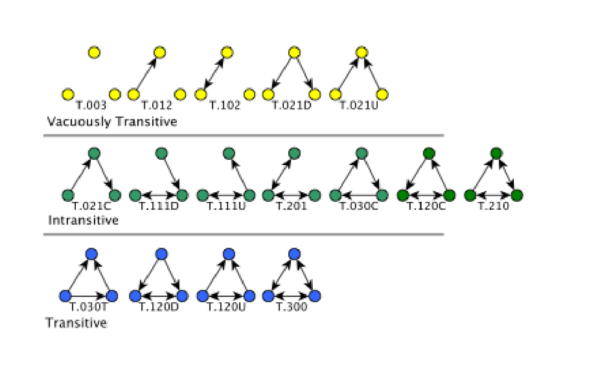

http://knoesis.wright.edu/sites/default/files/icnc15.pdf

### 6.1.3 Triads Tables

```r
datatable(triad_df_total)
```

|  | census_labels | tc_total | type |
| --- | --- | --- | --- |
| 1 | T.003 | 878877 | Vacuously Transitive |
| 2 | T.012 | 123065 | Vacuously Transitive |
| 3 | T.102 | 36095 | Vacuously Transitive |
| 4 | T.021D | 7384 | Vacuously Transitive |
| 5 | T.021U | 2749 | Vacuously Transitive |
| 6 | T.021C | 5247 | Intransitive |
| 7 | T.111D | 4187 | Intransitive |
| 8 | T.111U | 6634 | Intransitive |
| 9 | T.030T | 1000 | Transitive |
| 10 | T.030C | 85 | Intransitive |

[output cut: 6 more lines]

# 7 Transitivity - clustering coefficient

## 7.1 Transitivity Global

Socialnetwork is treated as an undirected network global - ratio of triangles (direction disregarded) to connected triples.

```r
transitivity(total, type="global")
```

```
## [1] 0.251101
```

# 8 Transitivity Local

Ratio of triangles to connected triples each vertex is part of.

```r
V(total)$transitivity_local<-transitivity(total, type="local")
total_transitivity_local<-transitivity(total, type="local") #local - ratio of triangles to connected triples each vertex is part of.
```

# 9 Descriptive Statistics for Local Transitivity by Vertex

```r
summary(total_transitivity_local[which(total_transitivity_local != Inf)])
```

```
##    Min. 1st Qu.  Median    Mean 3rd Qu.    Max.
##  0.0000  0.2314  0.3260  0.3606  0.4649  1.0000
```

```r
sd(total_transitivity_local[which(total_transitivity_local != Inf)])
```

```
## [1] 0.2015972
```

# 10 Barrat’s Weighted Transitivity by Edges (Barrat’s)

```r
V(total)$transitivity_barrat<-transitivity(total, weights=E(total)$weight, type="barrat")

total_transitivity_barrat<-transitivity(total, weights=E(total)$weight, type="barrat")
```

# 11 Descriptive Statistics for Barrat Weighted Transitivity by Vertex

```r
summary(total_transitivity_barrat[which(total_transitivity_barrat != Inf)])
```

```
##    Min. 1st Qu.  Median    Mean 3rd Qu.    Max.
##  0.0000  0.4456  0.6358  0.6646  0.8630  1.7640
```

```r
sd(total_transitivity_barrat[which(total_transitivity_barrat != Inf)])
```

```
## [1] 0.3210808
```

# 12 Transitivity Measures Dinamic Table

```r
#Getting  Measures

total_transitivity_local<-transitivity(total, type="local") %>% round(3)

total_transitivity_barrat<-transitivity(total, weights=E(total)$weight, type="barrat") %>% round(3)

#Creating a datagrame of measures
total_transitivity_df <- data.frame(total_transitivity_local,total_transitivity_barrat) %>% round(3)

#Adding type
total_transitivity_df <-cbind(total_transitivity_df, V(total)$LABEL_COR)

#Adding names
names(total_transitivity_df) <- c("Local", "Barrat's Weighted","Type")

#Ordering Variables
total_transitivity_df<-total_transitivity_df[c("Type", "Local", "Barrat's Weighted")]
```

## 12.1 General tabel - DT

```r
datatable(total_transitivity_df, filter = 'top')
```

|  | Type | Local | Barrat's Weighted |
| --- | --- | --- | --- |
| 1 | Assistência Hospitalar | 0.063 | 0.145 |
| 2 | Ambulatório de Saúde Mental | 0.074 | 0.157 |
| 3 | CAPSAD | 0.038 | 0.085 |
| 4 | CRAS/CREAS | 0.198 | 0.381 |
| 5 | CRAS/CREAS | 0.24 | 0.459 |
| 6 | CRAS/CREAS | 0.153 | 0.266 |
| 7 | Assistência Hospitalar | 0.055 | 0.148 |
| 8 | Entidades Assistênciais e Dependencia Química e CT | 0.184 | 0.357 |
| 9 | Entidades Assistênciais e Dependencia Química e CT | 0.363 | 0.556 |
| 10 | Entidades Assistênciais e Dependencia Química e CT | 0.41 | 0.698 |

[output cut: 177 more lines]

## 12.2 Aggregating data from previous table - mean

```r
aggdata_mean <-aggregate(total_transitivity_df, by=list(total_transitivity_df$Type), FUN=mean, na.rm=TRUE)

names(aggdata_mean) <- c("Group","Type","Local(M)", "Barrat's Weighted(M)")

#Removing Type variable
aggdata_mean<-aggdata_mean[,-c(2)]
```

## 12.3 Aggregating data from previous table - sd

```r
aggdata_sd <-aggregate(total_transitivity_df, by=list(total_transitivity_df$Type), FUN=sd, na.rm=TRUE)

names(aggdata_sd) <- c("Group","Type","Local(SD)", "Barrat's Weighted(SD)")

#Removing Type variable
aggdata_sd<-aggdata_sd[,-c(2)]
```

## 12.4 Merging mean and standart deviation

```r
total_table <- merge(aggdata_mean,aggdata_sd,by="Group")

#Rounding
Group<-total_table[,c(1)] #Keeping group
total_table<-total_table[,-c(1)] %>% round(3) #Rouding
total_table<-cbind(Group,total_table) #Binding toghter

#Organizing Variabels
total_table<-total_table[c("Group","Local(M)","Local(SD)", "Barrat's Weighted(M)","Barrat's Weighted(SD)")]
```

## 12.5 Final table with round - Transitivity

```r
datatable(total_table, filter = 'top')
```

|  | Group | Local(M) | Local(SD) | Barrat's Weighted(M) | Barrat's Weighted(SD) |
| --- | --- | --- | --- | --- | --- |
| 1 | Acolhimento Institucional | 0.272 | 0.02 | 0.542 | 0.057 |
| 2 | Ajuda Mútua | 0.418 | 0.296 | 0.63 | 0.38 |
| 3 | Ambulatório de Saúde Mental | 0.074 |  | 0.157 |  |
| 4 | Assistência Hospitalar | 0.194 | 0.108 | 0.378 | 0.195 |
| 5 | CAPS | 0.236 | 0.07 | 0.466 | 0.134 |
| 6 | CAPSAD | 0.038 |  | 0.085 |  |
| 7 | Consultório na Rua | 0.402 | 0.001 | 0.685 | 0.004 |
| 8 | CRAS/CREAS | 0.265 | 0.108 | 0.488 | 0.166 |
| 9 | Entidades Assistênciais e Dependencia Química e CT | 0.307 | 0.101 | 0.472 | 0.114 |
| 10 | Entidades Socioassistenciais | 0.278 | 0.099 | 0.471 | 0.178 |

[output cut: 3 more lines]

# 13 Saving objects with new variables and changes

```r
save.image("~/SNArRDJF/Robject/9_dyad_triad_total.RData")
```